# A Survey: Attitudes towards fermentation analyzed with Multiple Correspondence Analysis

Hervé Abdi, Dominique Valentin, & Sylvie Chollet

2020-08-22 18:45:04

# 1 Prelude

If you want to make sure that you have a clean start, you can execute the following commands:

```r
rm(list = ls())
graphics.off()
```

Or, better (see below, preamble), you can use an `Rproject` for this project.

# 2 Preamble

Make sure that your start this analysis a new `Rproject` so that the default directory will be correctly set.

Before we start the analysis, we need to have our standard packages installed (some from `Github`) and the corresponding libraries loaded:

- `Distatis`
- `ExPosition`
- `InPosition`
- `PTCA4CTA`
- `R4SPISE2018`
- `data4PCCAR`
- `dplyr` (to recode the data)
- `car` (to recode the data)
- `grid`, `gridExtra`, and `gTable` (to save tables as graphics, useful for power points)
- `stringi` (to recode strings)

and all their extensions:

```r
# Decomment all/some these lines if the packages are not installed
#_____________________________________________________________________
# # October 19, 2018. Temporary fix for an Rstudio problem
# # if this error message is generated:
# build_site()
# Error in eval(substitute(expr), data, enclos = parent.frame()) :
# is.character(repos) is not TRUE
# # from Rstudio team: as a temporary fix use these two lines
# repos <- getOption("repos")
# options(repos = setNames(as.character(repos), names(repos)))
#_____________________________________________________________________
#
# devtools::install_github('HerveAbdi/PTCA4CATA')
# devtools::install_github('HerveAbdi/DistatisR')
# devtools::install_github('HerveAbdi/data4PCCAR')
# devtools::install_github('HerveAbdi/R4SPISE2018') # of course!
#  install.packages('prettyGraphs')
#  install.packages('Matrix')
#  install.packages('dplyr')
#  install.packages('gridExtra')
#  install.packages('grid')
#  install.packages('gtable')
#  install.packages('stringi')
#  install.packages('printr')
#  install.packages('kableExtra')
#  load the libraries that we will need
# suppressMessages(library(Matrix))
suppressMessages(library(prettyGraphs))
suppressMessages(library(ExPosition))
suppressMessages(library(InPosition))
suppressMessages(library(DistatisR))
suppressMessages(library(PTCA4CATA))
suppressMessages(library(data4PCCAR))
suppressMessages(library(dplyr))
suppressMessages(library(gridExtra))    # to save a table as a graph
suppressMessages(library(grid))         # that will be saved in the
suppressMessages(library(gtable))       # powerpoint with the figures
# suppressMessages(library(printr))     # To pretty print tables
# suppressMessages(library(kableExtra)) # To pretty print tables
```

# 3 Introduction

## 3.1 File name for the power point to save the figures

The name for the PowerPoint presentation is stored in the variable `name4Graphs` as:

```r
name4Graphs = 'fermentationFrom2Countries_withJsup.pptx'
```

## 3.2 Parameters for the analysis: data file name

The data are stored in an excel file called `fermentedFoodSurvey.xlsx` that is stored with the present package and whose path can be recovered as:

```r
file2read.name     <- 'fermentedFoodSurvey.xlsx' # xls data file name
path2file <- system.file("extdata", file2read.name, package = "R4SPISE2018")
```

In the xls-file `fermentedFoodSurvey.xlsx`, the data are stored in the sheet called `dataMCA` whose name is stored in the variable `sheetName4Data`:

```r
sheetName4Data     <- 'dataMCA' # sheet name for the data
```

### 3.2.1 A peek at the data

The excel data file looks like the figure below:

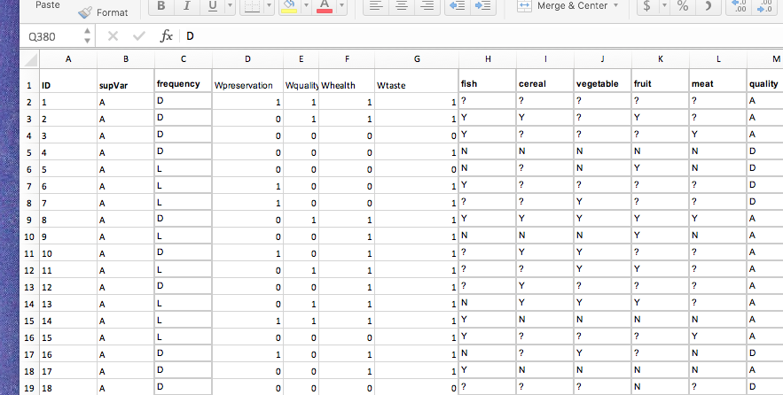

The Data Excel File

### 3.2.2 To replicate with different data

When you record you own data, make sure that you follow the same format, this way, the script described in this vignette will apply to your own analysis with minimal changes.

### 3.2.3 The general analytic strategy

We will first compute the results of the analysis, then create the graphics, and finally save everything into a PowerPoint presentation.

# 4 Run the statistical analyses

## 4.1 Read the (active and supplementary) data

The excel file name and location (i.e., path) are stored in the variable `path2file`. To read the data we use the function `DistatisR::read.df.excel()` (based upon the function `readxl::read_excel()`).

```r
rawData.tmp <- DistatisR::read.df.excel(path = path2file,
                             sheet = sheetName4Data)$df.data
#
```

The raw data are now read and stored in the data frame `rawData.tmp`. For these data to be used in an MCA, they need to be transformed into `factors` and stored in the data frame called `rawData`.

```r
# Transform the data into factors
rawData <- apply(rawData.tmp,2,as.factor)
```

## 4.2 Look at the data

The first thing in a survey is to look at the data and to select the questions that create enough differences between the respondents. A quick and dirty way top look at the data is to use the function `summary().`

```r
 knitr::kable( t( summary(rawData) ) )
```

| supVar | Length:403 | Class :character | Mode :character |
| --- | --- | --- | --- |
| frequency | Length:403 | Class :character | Mode :character |
| Wpreservation | Length:403 | Class :character | Mode :character |
| Wquality | Length:403 | Class :character | Mode :character |
| Whealth | Length:403 | Class :character | Mode :character |
| Wtaste | Length:403 | Class :character | Mode :character |
| fish | Length:403 | Class :character | Mode :character |
| cereal | Length:403 | Class :character | Mode :character |
| vegetable | Length:403 | Class :character | Mode :character |
| fruit | Length:403 | Class :character | Mode :character |
| meat | Length:403 | Class :character | Mode :character |
| quality | Length:403 | Class :character | Mode :character |
| industrial | Length:403 | Class :character | Mode :character |
| preservation | Length:403 | Class :character | Mode :character |
| health | Length:403 | Class :character | Mode :character |
| expensive | Length:403 | Class :character | Mode :character |
| taste | Length:403 | Class :character | Mode :character |
| trust | Length:403 | Class :character | Mode :character |
| clear | Length:403 | Class :character | Mode :character |
| innovation | Length:403 | Class :character | Mode :character |
| sex | Length:403 | Class :character | Mode :character |
| age | Length:403 | Class :character | Mode :character |
| occupation | Length:403 | Class :character | Mode :character |
| nation | Length:403 | Class :character | Mode :character |

### 4.2.1 A bit more on the variables

The following set of variables corresponds to the demographics of the participants: `Sex`, coded as `M` vs `W`; `Age`, coded as less then 25 (`<25`) and more than 25 (`>25`); Occupation binarized as “Food or microbiology” (`FM`) versus `other` and Nationality (`nation`) code with two levels French (`F`) versus Vietnamese (`VN`).

To know more about the questions, you can have a look at the questionnaire `questionnaireFermentation.pdf` that you can find in the directory that you can recover from the variable `path2file`.

## 4.3 Analysis plan

The data were previously “cleaned” so that we only kept for this example questions that created differences between the respondents.

### 4.3.1 Supplementary variables

Here we decided to treat as supplementary variables the demographics of the respondents: Sex `(sex)`, Age `(age)`, `occupation`, and their country of residence `(nation)`.

### 4.3.2 Supplementary observations

The original data come from a survey that was performed to explore the similarity and differences of two populations (i.e., Vietnam and France) about fermented products. The original participants of the study constitute the *active* observations.

During the SPISE2018 workshop we also asked the participants to fill in the same questionnaire. These new observations are not used to compute the MCA but are projected later on as *supplementary* elements.

## 4.4 Selection of variables and recoding

In MCA, the data need to be recoded as nominal variables with the constraint that the different levels of a given variable are roughly balanced. When all the variables are naturally nominal, the process is straightforward but some categories may need to be fused to have the levels roughly balanced. For ordinal or quantitative data, the procedure is to bin the data so that the bins are roughly balanced.

## 4.5 From one dataframe to the other

From the dataframe `rawData` we now create the new dataframe `cleanData`. It will have the same rows but the columns are obtained by recoding the columns of `rawData.`

The first step is to create the new data frame with only the variables we want to use, we also re-order the variables to have the respondent variables (i.e., Sex, Age, city) first. This is done with this line of code:

```r
temp.df <- dplyr::select(as.data.frame(rawData),
                         supVar,
                         sex , age, occupation, nation, frequency,
                         Wpreservation, Wquality, Whealth, Wtaste,
                         fish, cereal,  vegetable, fruit, meat,
                         quality, industrial, preservation, health,
                         expensive, taste, trust, clear, innovation)
```

### 4.5.1 Participants’ description

to make the results and graphs more readable, we recode the levels of some variables to shorter names

```r
temp.df[,'age'] <- plyr::mapvalues(temp.df[,'age'],
                          from = c("<25", ">25"), to = c("Y", "O"))
temp.df[,'occupation'] <- plyr::mapvalues(temp.df[,'occupation'],
                          from = c("FM", "other"), to = c("F", "O"))
temp.df[,'nation'] <- plyr::mapvalues(temp.df[,'nation'],
                          from = c("F", "VN"), to = c("F", "V"))
```

### 4.5.2 New cleaned data set(s)

We can now put together the new data sets. Note that in this example the supplementary observations were stored in the same excel sheet as the active data but the supplementary observations’ names all start the letter `S`. The status of the observations (i.e., active vs. supplementary) is recorded in the variable `supVar` that we will use to subset the observations into the active set of observations (stored in the data frame `cleanData`) and the supplementary set of observations (stored in the data frame `cleanData.sup`).

```r
cleanData.tmp <- temp.df
cleanData.tmp <- cleanData.tmp[complete.cases(cleanData.tmp),]
cleanData.allVar <- cleanData.tmp[cleanData.tmp[,1] == 'A', 2:ncol(cleanData.tmp)]
cleanData.varSup <- cleanData.allVar[,1:4]
cleanData        <- cleanData.allVar[,5:ncol(cleanData.allVar)]
cleanData.sup <- cleanData.tmp[cleanData.tmp[,1] == 'S', 6:ncol(cleanData.tmp)]
```

The different dataframes are now ready to be analyzed with multiple correspondence analysis: * `cleanData` contains the active observations and variables, * `cleanData.sup` contains the supplementary observations, * `cleanData.varSup` contains the supplementary variables.

# 5 Multiple Correspondence Analysis

## 5.1 MCA for the active set

We use the package `ExPosition` to compute the MCA

```r
resMCA <- epMCA(cleanData, graphs = FALSE)
```

## 5.2 Supplementary observations

To compute the supplementary projections, we use the function `ExPosition::supplementaryRows()`. But before using this function, we need to prepare the supplementary data. To do so, we need to transform the supplementary data from a data frame with variables being factors to a new data frame with 0/1 columns (with as many 0/1 columns as there are levels for this variable). For this transformation to be correctly done, it needs to be done on the merged data set (i.e., active + supplementary). All this is done with the code below

```r
# recode the factors as set of 0/1 variables
testclean <- makeNominalData(rbind(cleanData,cleanData.sup))
clean.Sup <-  testclean[cleanData.tmp[,1] == 'S',]
# barycentric code for nation
#clean.Sup[,(colnames(testclean) %in% 'nation.F')] <- .5
#clean.Sup[,(colnames(testclean) %in% 'nation.V')] <- .5
#
resMCA.sup <- supplementaryRows(SUP.DATA = clean.Sup, res = resMCA)
colnames(resMCA.sup$fii) <- paste0('Dimension ',
                                1:ncol(resMCA.sup$fii))
```

## 5.3 Supplementary variables

To project the supplementary variables, we need first to convert the dataframe containing the variables coded as factors into a matrix of 0/1 columns (with as many 0/1 columns as there are levels for this variable), and then cal the `ExPosition` function `supplementaryCols`:

```r
#
resMCA.varSup <- supplementaryCols(SUP.DATA = makeNominalData(cleanData.varSup),
                                        res = resMCA)
colnames(resMCA.varSup$fjj) <- paste0('Dimension ',
                                1:ncol(resMCA.varSup$fjj))
```

## 5.4 Inferences

Inferences are performed with the package `InPosition` as:

```r
resMCA.inf <- epMCA.inference.battery(cleanData, graphs = FALSE)
```

# 6 Graphics

Here we first plot the histogram of the eigenvalues (i.e., the “scree”). then we make the standard graphs for the variables, for the levels of the active and supplementary variables, for the active and supplementary observations, and then for the supplementary observations.

## 6.1 Screes for MCA

### 6.1.1 Plain Scree

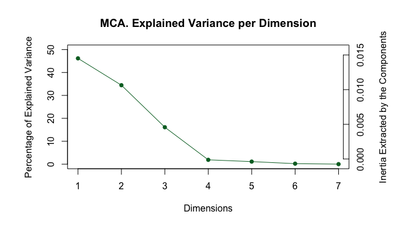

```r
scree.mca <- PlotScree(ev = resMCA$ExPosition.Data$eigs,
                    title = "MCA. Explained Variance per Dimension")
```

```r
b0001a.Scree <- recordPlot() # Save the plot
```

### 6.1.2 Scree with inference

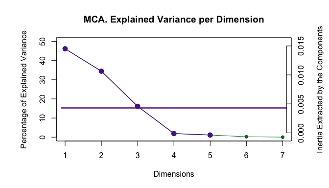

```r
scree.mca <- PlotScree(ev = resMCA$ExPosition.Data$eigs,
               p.ev = resMCA.inf$Inference.Data$components$p.vals,
               plotKaiser = TRUE,
               title = "MCA. Explained Variance per Dimension")
```

```r
b0001b.Scree <- recordPlot() # Save the plot
```

## 6.2 The (qualitative) Variables

### 6.2.1 Get some colors for the variables

```r
cJ <- resMCA$ExPosition.Data$cj
color4Var <- prettyGraphs::prettyGraphsColorSelection(ncol(cleanData))
```

### 6.2.2 Heatmap for correlations between variables

The equivalent of a correlation matrix can be obtained in MCA by computing the $\phi^2$ correlation matrix associated to the Burt-table derived from the 0/1 matrix. This is obtained from the following code:

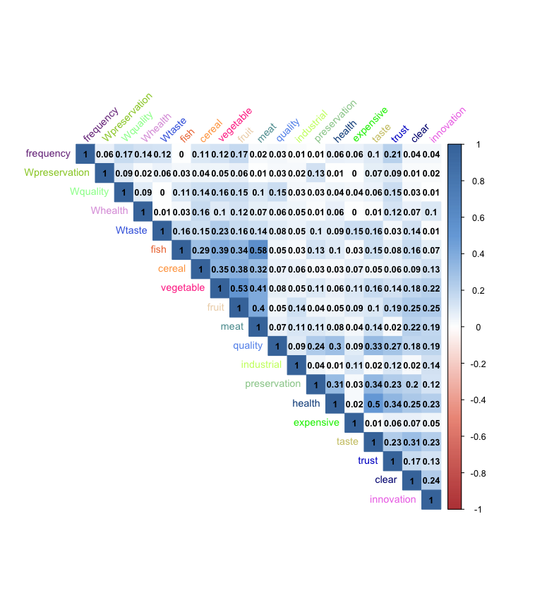

```r
# Pseudo Heat Map. Correlation ----
# We need correlation to compare with PCA
corrMatBurt.list <- phi2Mat4BurtTable(cleanData)
col <- colorRampPalette(c("#BB4444", "#EE9988", "#FFFFFF", "#77AADD", "#4477AA"))

corr4MCA.r <- corrplot::corrplot(
         as.matrix(corrMatBurt.list$phi2.mat^(1/2)),# to get correlations
         method="color", col=col(200),
         type="upper",
         addCoef.col = "black", # Add coefficient of correlation
         tl.col = color4Var,
         tl.cex = .9,
         tl.srt = 45, #Text label color and rotation
         number.cex = .8,
         diag = TRUE # needed to have the color of variables correct
         )
```

```r
# dev.new()
a0000.corMat.phi <- recordPlot()
```

### 6.2.3 Variable contributions

The contributions for the variables can be obtained from the function `data4PCCAR::ctr4Variables` as:

```r
varCtr <- data4PCCAR::ctr4Variables(cJ)
rownames(color4Var) <- rownames(varCtr)
```

The contribution of a variable is the sum of the contributions of all its levels. This statistics measures the importance of this variable for a given dimension.

```r
nFact <- min(5, ncol(cJ) - 1)
#knitr::kable(round( varCtr[,1:nFact]*1000 ) )
# save table as a graph
ctrTable <- tableGrob(round(varCtr[,1:nFact]*1000))
h <- grobHeight(ctrTable)
w <- grobWidth(ctrTable)
title <- textGrob("Variable Contributions",
                 y = unit(0.5,"npc") + 0.92*h,
                 # fine tune the position of the title
                  just = "centre",
                  gp = gpar(fontsize = 14))
TableWithTitle <- gTree(children = gList(ctrTable, title))
```

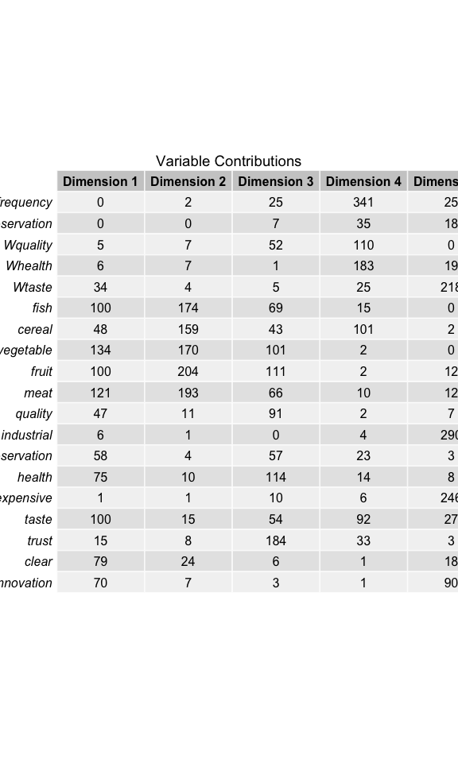

Variable Contributions (per mille).

```r
# Note: Potential problems with grid.draw(). If it does not plot
# recordPlot() will fail and the graph will not be saved in the powerpoint
# and will generate a strange error message
grid.draw(TableWithTitle)
```

```r
#a0000.2.ctrTable  <- recordPlot()
```

To create graphics we will color the different levels of a variable with the same color. First we create the vector storing the color with the function `data4PCCAR::coloringLevels`:

```r
col4Levels <- data4PCCAR::coloringLevels(
                       rownames(resMCA$ExPosition.Data$fj), color4Var)
col4Labels <- col4Levels$color4Levels
```

As an alternative to the table of contributions, we can display the contributions with some bar plots. Note that these bar plots need some “tweaking” to correctly works.

#### 6.2.3.1 Variable contributions Dimension 1.

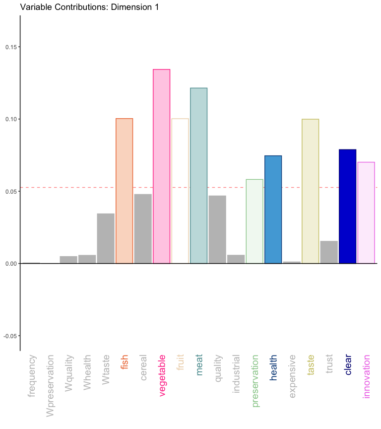

```r
varCtr1 <- varCtr[,1]
names(varCtr1) <- rownames(varCtr)
a0005.Var.ctr1  <- PrettyBarPlot2(varCtr1,
                    main = 'Variable Contributions: Dimension 1',
                                ylim = c(-.05, 1.2*max(varCtr1)),
                                font.size = 5,
                                threshold = 1 / nrow(varCtr),
                                color4bar = gplots::col2hex(color4Var)
)
print(a0005.Var.ctr1)
```

#### 6.2.3.2 Variable contributions Dimension 2.

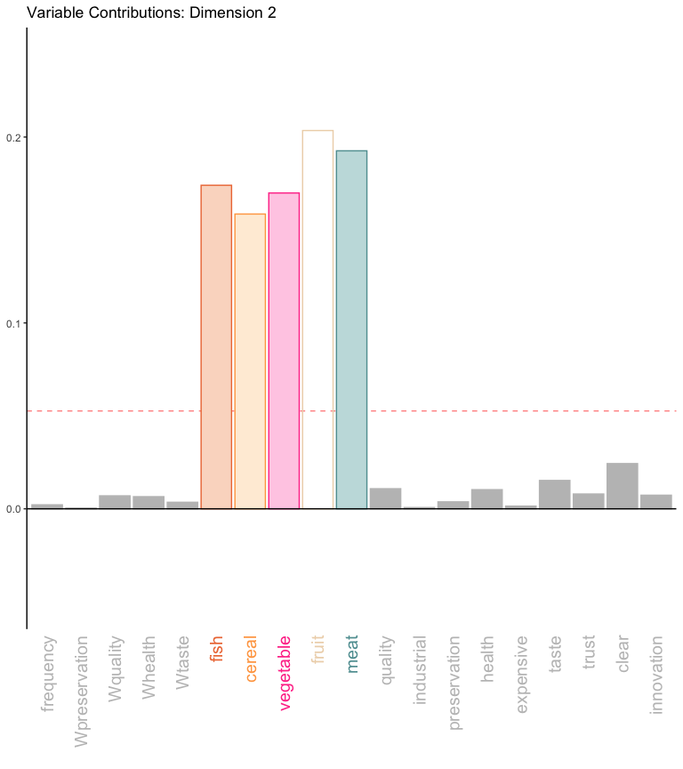

```r
varCtr2 <- varCtr[,2]
names(varCtr2) <- rownames(varCtr)
a0006.Var.ctr2  <- PrettyBarPlot2(varCtr2,
                    main = 'Variable Contributions: Dimension 2',
                                ylim = c(-.05, 1.2*max(varCtr2)),
                                threshold = 1 / nrow(varCtr),
                                font.size = 5,
                                color4bar = gplots::col2hex(color4Var)
)
print(a0006.Var.ctr2)
```

#### 6.2.3.3 Variable contributions Dimension 3.

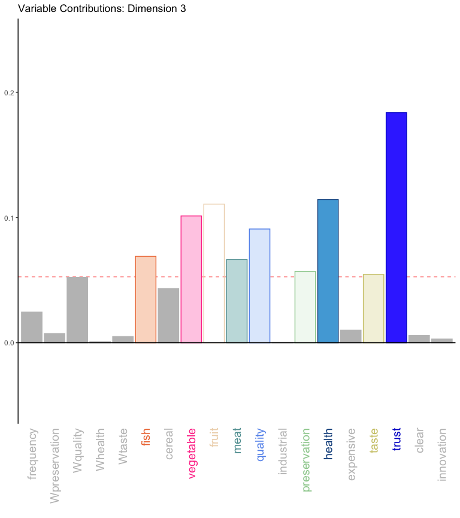

```r
varCtr3 <- varCtr[,3]
names(varCtr3) <- rownames(varCtr)
a0006.Var.ctr3  <- PrettyBarPlot2(varCtr3,
                    main = 'Variable Contributions: Dimension 3',
                                ylim = c(-.05, 1.2*max(varCtr2)),
                                threshold = 1 / nrow(varCtr),
                                font.size = 5,
                                color4bar = gplots::col2hex(color4Var)
)
print(a0006.Var.ctr3)
```

#### 6.2.3.4 Pseudo factor plots with variable contributions

Another way to visualize the variable contributions is to use a pseudo-factor plot with the contributions:

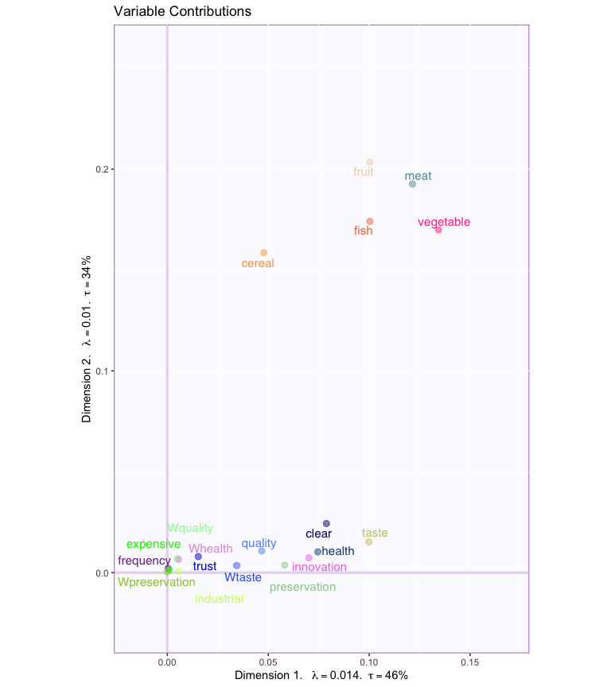

```r
ctrV12 <- PTCA4CATA::createFactorMap(X =  varCtr,
                        title = "Variable Contributions",
                        col.points = color4Var,
                        col.labels = color4Var,
                        alpha.points = 0.5,
                        cex = 2.5,
                        alpha.labels = 1,
                        text.cex = 4,
                        font.face = "plain",
                        font.family = "sans")

ctr.labels <- createxyLabels.gen(
  1,2, lambda = resMCA$ExPosition.Data$eigs,
  tau = resMCA$ExPosition.Data$t
)
a0007.Var.ctr12  <- ctrV12$zeMap  + ctr.labels
#
print(a0007.Var.ctr12)
```

#### Variable contribution plot with important variables only

```r
var12 <- data4PCCAR::getImportantCtr(ctr = varCtr,
                           eig = resMCA$ExPosition.Data$eigs)
importantVar <- var12$importantCtr.1or2
col4ImportantVar <- color4Var
col4NS <- 'gray90'
col4ImportantVar[!importantVar] <- col4NS
```

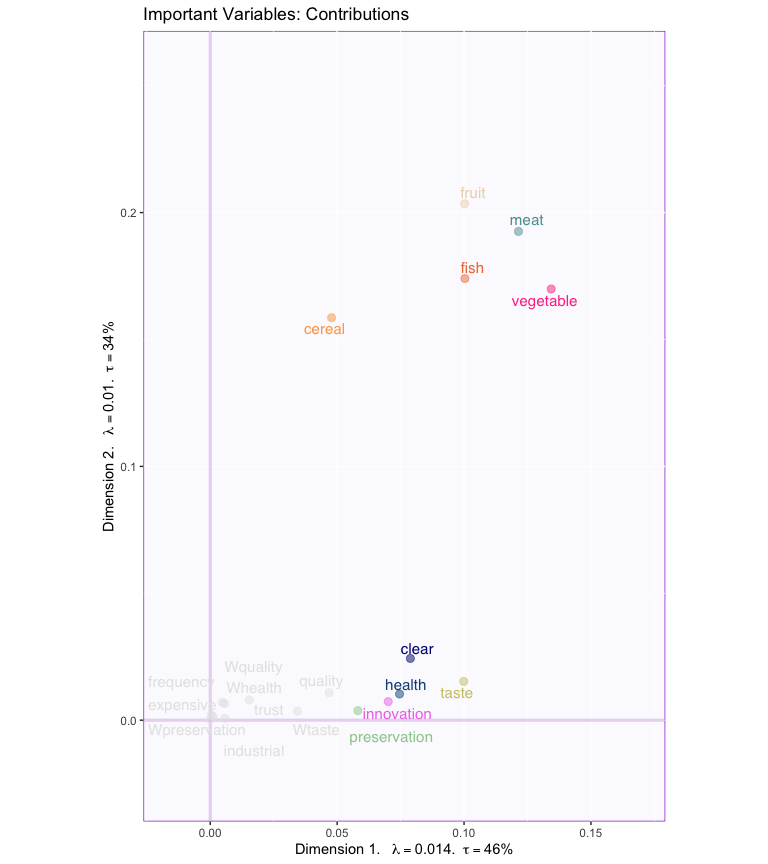

```r
ctrV12.imp <- PTCA4CATA::createFactorMap(X =  varCtr,
                        title = "Important Variables: Contributions",
                        col.points = col4ImportantVar,
                        col.labels = col4ImportantVar,
                        alpha.points = 0.5,
                        cex = 2.5,
                        alpha.labels = 1,
                        text.cex = 4,
                        font.face = "plain",
                        font.family = "sans")
a0008.Var.ctr12.imp  <- ctrV12.imp$zeMap  + ctr.labels
#
print(a0008.Var.ctr12.imp)
```

#### 6.2.3.5 Variable contribution map with Dimensions 2 & 3

```r
#
var32 <-  data4PCCAR::getImportantCtr(ctr = varCtr,
                                    eig = resMCA$ExPosition.Data$eigs,
                                    axis1 = 3, axis2 = 2)
importantVar23 <- var32$importantCtr.1or2
col4ImportantVar23 <- color4Var
col4NS <- 'gray90'
col4ImportantVar23[!importantVar23] <- col4NS
```

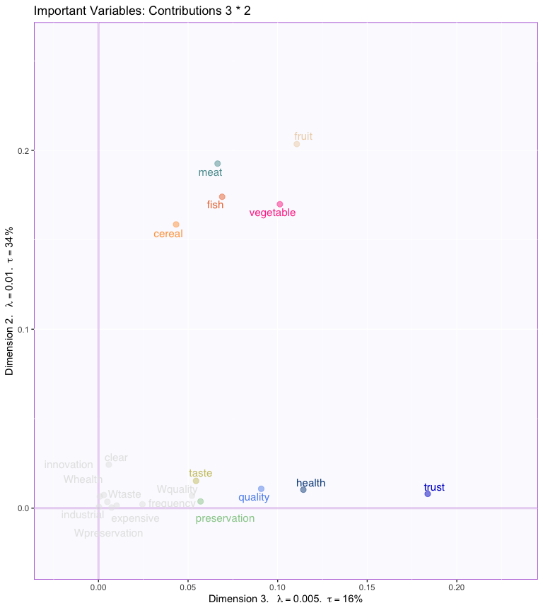

```r
ctrV23.imp <- PTCA4CATA::createFactorMap(X =  varCtr,
                                         axis1 = 3, axis2 = 2,
                        title = "Important Variables: Contributions 3 * 2",
                        col.points = col4ImportantVar23,
                        col.labels = col4ImportantVar23,
                        alpha.points = 0.5,
                        cex = 2.5,
                        alpha.labels = 1,
                        text.cex = 4,
                        font.face = "plain",
                        font.family = "sans")
ctr.labels23 <- createxyLabels.gen(
  3,2, lambda = resMCA$ExPosition.Data$eigs,
  tau = resMCA$ExPosition.Data$t
)
a0009.Var.ctr23.imp  <- ctrV23.imp$zeMap  + ctr.labels23
#
print(a0009.Var.ctr23.imp)
```

### 6.2.4 Qualitative variables pseudo-*F* and pseudo-$BR$

The contribution of a variable to a dimension measures the importance of this variable for the dimension but it does not evaluates its significance, stability, or replicability. In a standard PCA, this evaluation is performed with pseudo-$t$ values called bootstrap ratios obtained through resampling. In MCA, the standard inference procedures provide bootstrap ratios only for the levels of the variables and, so these bootstrap-ratios need to be combined to create *pseudo-bootstrap* ratio for the qualitative variables.

In a similar way to the variable contribution graphs we can plot these pseudo-bootstrap ratios. The graph of the bootstrap ratios and contributions often look similar but they provide different types of information. Contributions are descriptive statistics indicating the importance of a variable (akin to a standard $R^2$) whereas (pseudo-) bootstrap ratios are inferential statistics (akin to a $t$-test) that combine importance and sample size.

#### 6.2.4.1 Computing pseudo-bootstrap ratios

##### 6.2.4.1.1 From BRs to an $F$

If we assume that all levels of the variable are balanced, pseudo-$F$ ratios for the $K$ qualitative variables can also be obtained from the bootstrap ratios with the formula:
$$F_k = \frac{J_k}{J_k-1} \sum_{j}^{J_k} t_{k}^2$$
where $J_k$ (respectively $t_k$) is the number of levels (respectively bootstrap ratios) for the $k$-th qualitative variable.

If we want to take into account the frequency of the different levels of a qualitative variable, and if we denote by $w_{j(k)}$ the frequency of level $j$ of the $k$-th variable, the pseudo-$F$ ratios can be computed as:
$$F_k = \frac{J_k}{J_k-1} \sum_{j}^{J_k} w_{j(k)} t^2.$$

These pseudo-$F$ ratios evaluate if a dimension of the MCA creates a reliable difference between the levels of a qualitative variable; by contrast, a column bootstrap ratio evaluates if this column systematically loads on the same side of a given dimension.

##### 6.2.4.1.2 From $F$ to $p(F)$ to pseudo-$BR$

To display the pseudo-$F$ ratios in a similar way (i.e., with the same `R`-functions) as the bootstrap ratios, it is convenient to transform the pseudo-$F$ into pseudo bootstrap ratios. To do so, the pseudo-$F$ ratios are re-scaled to pseudo-$BR$ in two steps: First the pseudo-$F$ and its degrees of freedom are used to compute the $p$ value associated to the computed $F$ value and this probability is then, in turn, used to compute the corresponding value of the $BR$ that would have generated the $p$-value. For example, an $F$ of 3.13 computed for a variable with 4 levels (and so 3 degrees of freedom) and 1,000 bootstrapped iterations will have an associated $p$-value of .025 which will, in turn, correspond to a pseudo-BR of $1.96$.

Note that a positive pseudo $BR$ corresponds to the standard $F$ ratio testing for differences between the levels of a qualitative variable, whereas a *negative* $BR$ is testing for the *homogeneity*, an effect which would indicate that the levels of the variables are too similar than they should be under the null (an effect sometimes called a *strawberry basket* by statisticians, for more details, see, e.g., Abdi, Edelman, Valentin, & Dowling, 2009).

The computations of the pseudo-$BR$ for the qualitative variables are performed by the function `data4PCCAR::BR4varMCA`, as illustrated below:

```r
# Get the pseudo Bootstrap Ratios
BrLevels <- resMCA.inf$Inference.Data$fj.boots$tests$boot.ratios
wJ       <- 1 / resMCA.inf$Fixed.Data$ExPosition.Data$W
nIter    <- 1000
Br4Variables <- data4PCCAR::BR4varMCA(BrLevels, wJ, nIter)
```

##### 6.2.4.1.3 Pseudo-BR Dimension 1

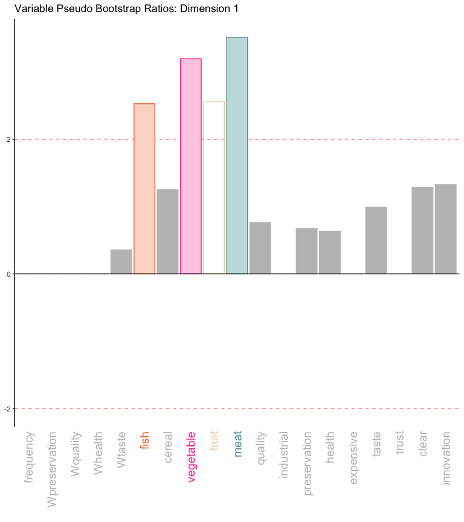

```r
VarBR1 <- Br4Variables$pseudoBR.pos[,1]
c0010.Var.br1  <- PrettyBarPlot2(VarBR1,
                    main = 'Variable Pseudo Bootstrap Ratios: Dimension 1',
                               ylim = 2,
                                threshold = 2,
                                font.size = 5,
                                color4bar = gplots::col2hex(color4Var)
)
print(c0010.Var.br1)
```

##### 6.2.4.1.4 Pseudo-BR Dimension 2

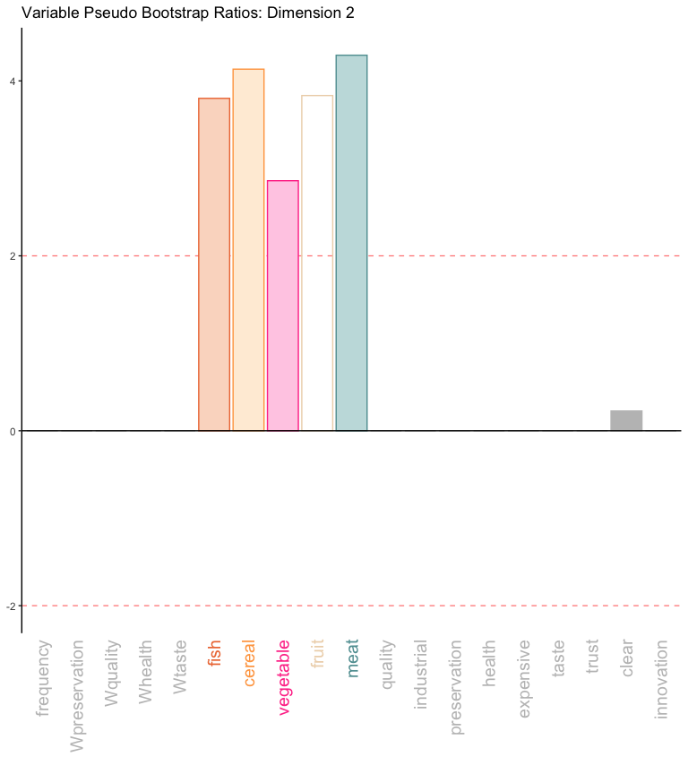

```r
VarBR2 <- Br4Variables$pseudoBR.pos[,2]
c0011.Var.br2  <- PrettyBarPlot2(VarBR2,
                    main = 'Variable Pseudo Bootstrap Ratios: Dimension 2',
                               ylim = 2,
                                threshold = 2,
                                font.size = 5,
                                color4bar = gplots::col2hex(color4Var)
)
print(c0011.Var.br2)
```

##### 6.2.4.1.5 Pseudo-BR Dimension 3

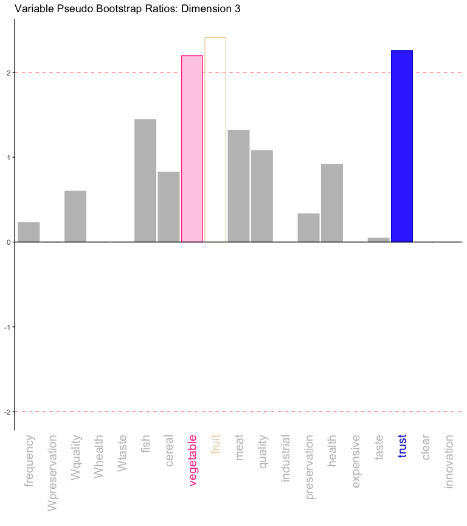

```r
VarBR3 <- Br4Variables$pseudoBR.pos[,3]
c0012.Var.br3  <- PrettyBarPlot2(VarBR3,
                    main = 'Variable Pseudo Bootstrap Ratios: Dimension 3',
                               ylim = 2,
                               threshold = 2,
                               font.size = 5,
                               color4bar = gplots::col2hex(color4Var)
)
print(c0012.Var.br3)
```

## 6.3 Maps for the levels of variables (i.e., columns)

### 6.3.1 Levels of variables: plain map, Dimensions 1 & 2

```r
axis1 = 1
axis2 = 2
Fj <- resMCA$ExPosition.Data$fj
# generate the set of maps
BaseMap.Fj <- createFactorMap(X = Fj , # resMCA$ExPosition.Data$fj,
                              axis1 = axis1, axis2 = axis2,
                              title = 'MCA. Variables',
                              col.points = col4Labels, cex = 1,
                              col.labels = col4Labels, text.cex = 2.5,
                              force = 2)
# add labels
labels4MCA <- createxyLabels.gen(x_axis = axis1, y_axis = axis2,
               lambda = resMCA$ExPosition.Data$eigs,
               tau = resMCA$ExPosition.Data$t)
# make the maps
b0002.BaseMap.Fj <- BaseMap.Fj$zeMap + labels4MCA
b0003.BaseMapNoDot.Fj  <- BaseMap.Fj$zeMap_background +
                          BaseMap.Fj$zeMap_text + labels4MCA
```

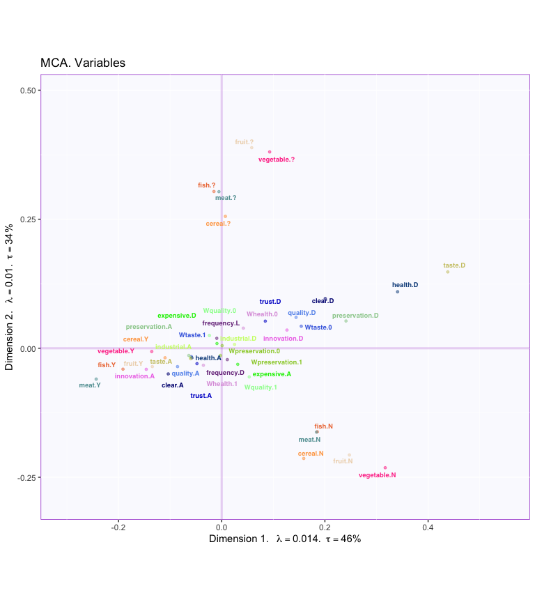

```r
print(b0002.BaseMap.Fj)
```

### 6.3.2 Levels of variables: map with only important variables

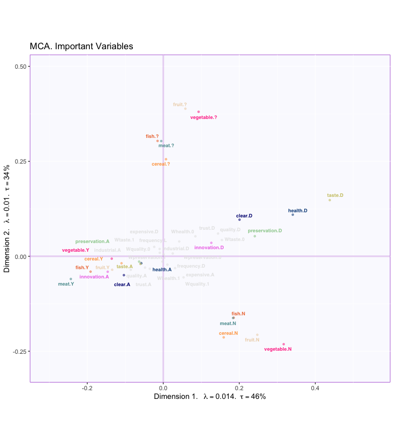

```r
col4Levels.imp <- data4PCCAR::coloringLevels(rownames(Fj),
                                             col4ImportantVar)
BaseMap.Fj.imp <- createFactorMap(X = Fj , # resMCA$ExPosition.Data$fj,
                              axis1 = axis1, axis2 = axis2,
                              title = 'MCA. Important Variables',
                      col.points = col4Levels.imp$color4Levels,
                              cex = 1,
                      col.labels = col4Levels.imp$color4Levels,
                              text.cex = 2.5,
                              force = 2)
b0010.BaseMap.Fj <- BaseMap.Fj.imp$zeMap + labels4MCA
print(b0010.BaseMap.Fj)
```

### 6.3.3 Levels of variables: map with important variables and lines

The MCA map for the variables is easier to read when the levels of a qualitative variable are linked to each other with lines as show below

```r
lines4J <- addLines4MCA(Fj, col4Var = col4Levels.imp$color4Variables, size = .7)
 b0020.BaseMap.Fj <-  b0010.BaseMap.Fj + lines4J
 print( b0020.BaseMap.Fj)
```

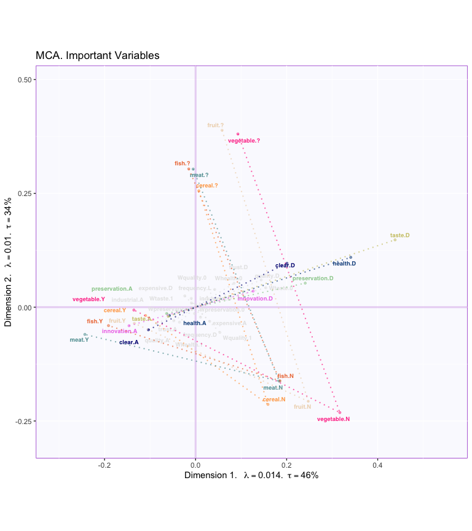

```r
zeNames          <- getVarNames(rownames(Fj))
importantsLabels <- zeNames$stripedNames %in% zeNames$variableNames[importantVar]
Fj.imp <- Fj[importantsLabels,]
lines4J.imp <- addLines4MCA(Fj.imp,
                            col4Var = col4Levels$color4Variables[which(importantVar)],
                            size = .9, linetype = 3, alpha = .5)
 b0021.BaseMap.Fj <-  b0010.BaseMap.Fj + lines4J.imp
 print( b0021.BaseMap.Fj)
```

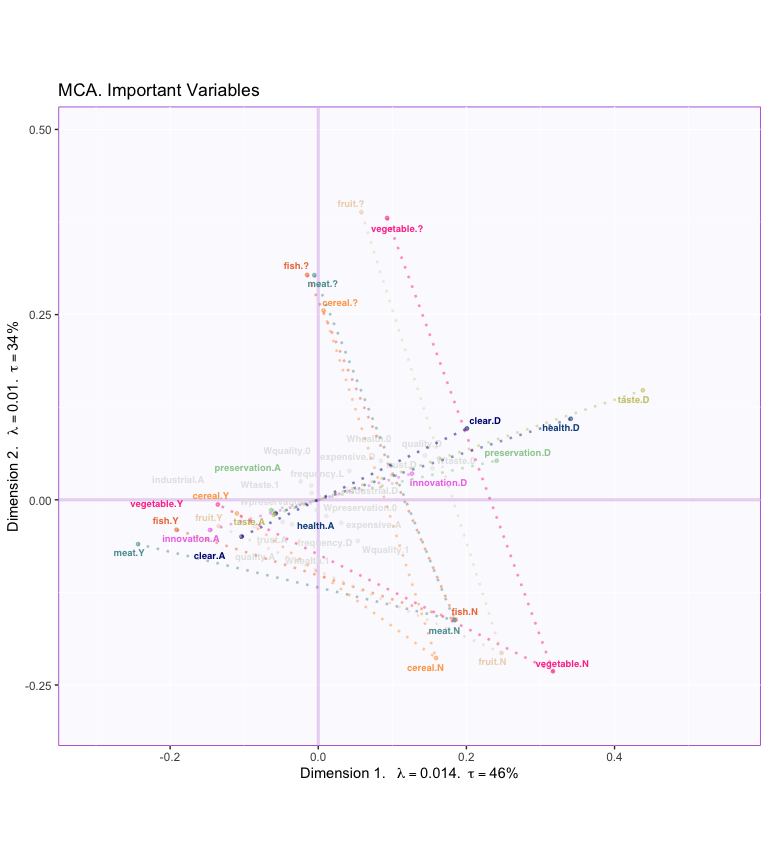

### 6.3.4 Levels of variables: Map for Dimensions 2 & 3

Have a look at the map for Dimensions 2 and 3.

```r
col4Levels23.imp <- data4PCCAR::coloringLevels(rownames(Fj),
                                             col4ImportantVar23)
axis3 = 3
BaseMap.Fj23.imp <- createFactorMap(X = Fj , # resMCA$ExPosition.Data$fj,
                              axis1 = axis3, axis2 = axis2,
                              title = 'MCA. Important Variables. Dimensions 2 & 3',
                      col.points = col4Levels23.imp$color4Levels,
                              cex = 1,
                      col.labels = col4Levels23.imp$color4Levels,
                              text.cex = 2.5,
                              force = 2)
labels4MCA23 <- createxyLabels.gen(x_axis = axis3, y_axis = axis2,
               lambda = resMCA$ExPosition.Data$eigs,
               tau = resMCA$ExPosition.Data$t)
b0030.BaseMap.Fj23 <- BaseMap.Fj23.imp$zeMap + labels4MCA23

# zeNames          <- getVarNames(rownames(Fj))
importantsLabels23 <- zeNames$stripedNames %in% zeNames$variableNames[importantVar23]
Fj23.imp <- Fj[importantsLabels23,]
lines4J23.imp <- addLines4MCA(Fj23.imp,
                    col4Var = col4Levels$color4Variables[
                               which(importantVar23)],
                    axis_h = axis3,
                    axis_v = axis2,
                    size = .9, linetype = 3, alpha = .5)
 b0031.BaseMap.Fj23 <-  b0030.BaseMap.Fj23 + lines4J23.imp
 print( b0031.BaseMap.Fj23)
```

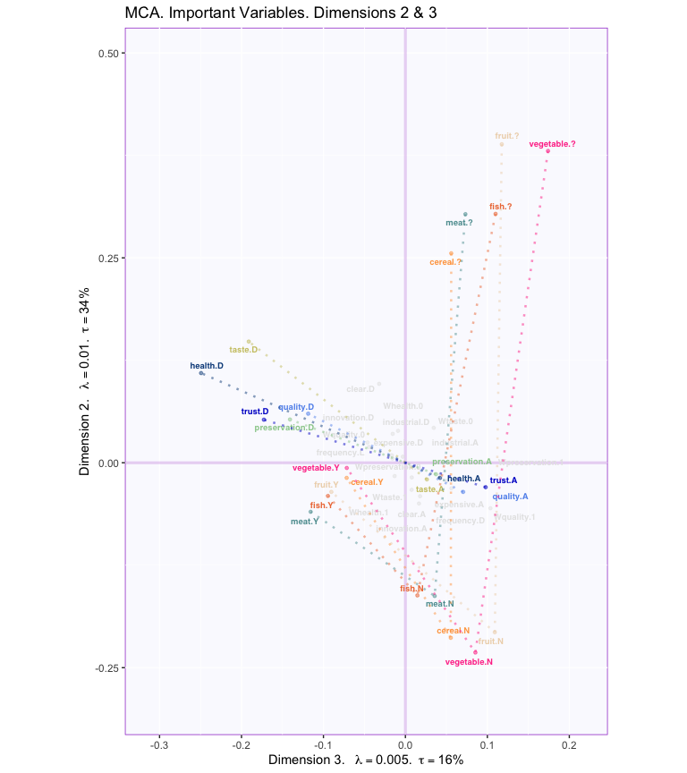

### 6.3.5 Levels of variables: Maps with supplementary variables

To facilitate the interpretations of the map, we can add the supplementary variables to the variable map, as shown below:

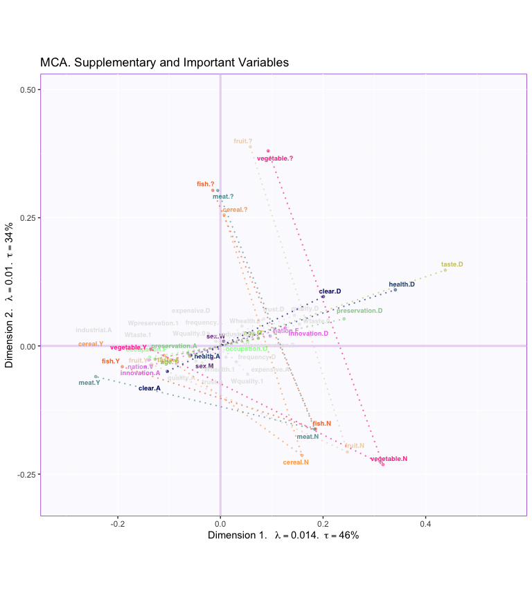

```r
col4VarSup <- prettyGraphs::prettyGraphsColorSelection(ncol(cleanData.varSup))
Fj.sup <- resMCA.varSup$fjj
col4Levels.sup <- data4PCCAR::coloringLevels(rownames(Fj.sup), col4VarSup)
BaseMap.Fj.sup <- createFactorMap(X = Fj.sup , # resMCA$ExPosition.Data$fj,
                axis1 = axis1, axis2 = axis2,
                constraints  = BaseMap.Fj$constraints, # to get same size
                title = 'MCA. Supplementary and Important Variables',
                col.points = col4Levels.sup$color4Levels,
                              cex = 1,
                col.labels = col4Levels.sup$color4Levels,
                text.cex = 2.5,
                force = 2)
lines4J.sup <- addLines4MCA(Fj.sup,
                  col4Var = col4Levels.sup$color4Variables, size = .7)
b0030.Sup.Fj <- BaseMap.Fj.sup$zeMap +
                     BaseMap.Fj.imp$zeMap_dots +
                     BaseMap.Fj.imp$zeMap_text +
                     labels4MCA +
                     lines4J + lines4J.sup
print(b0030.Sup.Fj)
```

This last map can easier to read if we plot only the supplementary variables.

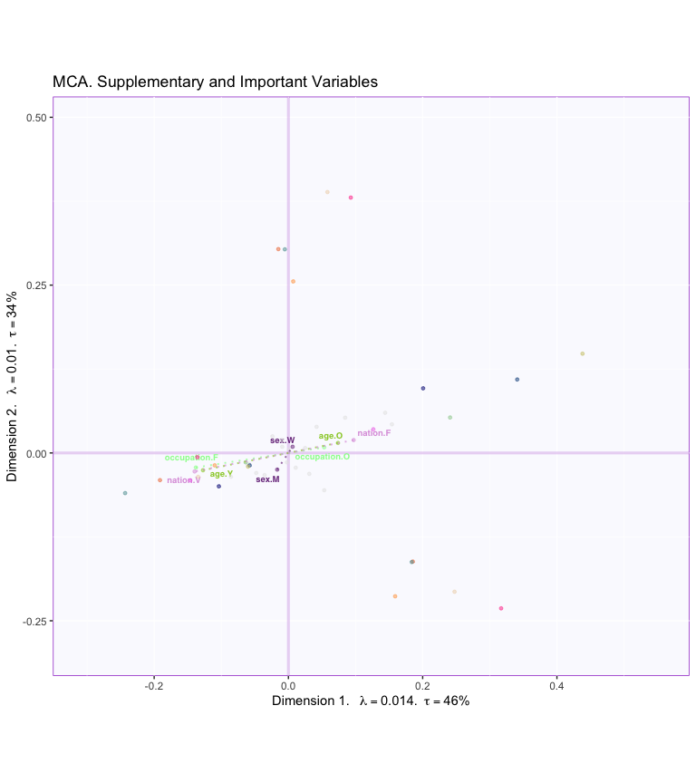

```r
b0031.Sup.Fj.only <- BaseMap.Fj.sup$zeMap +
                     BaseMap.Fj.imp$zeMap_dots +
                     labels4MCA +
                      lines4J.sup
print(b0031.Sup.Fj.only)
```

The plots of the supplementary variables suggest that Dimension 1 expresses a difference between young, (often food professionals), Vietnamese respondents versus older, (mostly non food professional), French respondents (a pattern indicating a potential confound of the `age` and `nation` variables). We will explore this difference between Vietnamese and French respondents by coloring, in their maps, the respondents according to their nationality.

### 6.3.6 Bootstrap ratios for levels of variables

Just like in PCA, the significance of each column (i.e., level of a qualitative variable) can be assessed with a bootstrap ratio. For example, the bootstrap ratios for all levels of all qualitative variables for Dimension 1 are plotted as

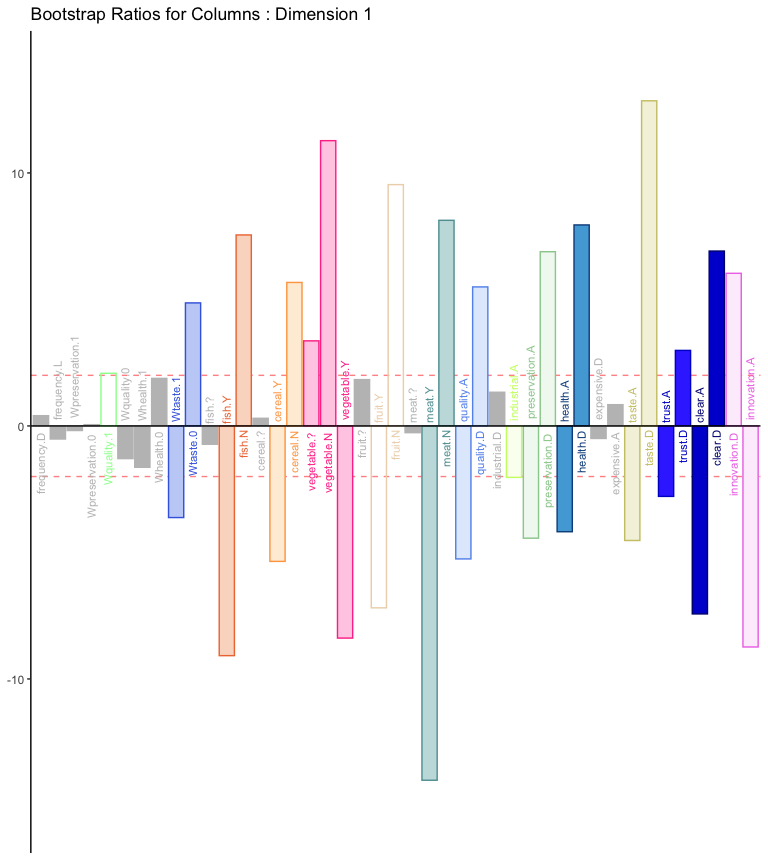

```r
c0001.Levels.BR  <- PrettyBarPlot2(
      resMCA.inf$Inference.Data$fj.boots$tests$boot.ratios[,1], # BR
                    main = 'Bootstrap Ratios for Columns : Dimension 1',
                             threshold = 2,
                             color4bar = gplots::col2hex(col4Labels)
)
print(c0001.Levels.BR)
```

## 6.4 Maps for the observations

Here we color the observations by `nation,` to better understand how this variable could explain some of the variability in for this data set (the projection of `nation` as a supplementary variable was already suggesting that this variable is related to Dimension 1).

```r
Fi <- resMCA$ExPosition.Data$fi
colCity <- c('darkblue', 'red4')
nI <- nrow(Fi)
col4I.City <- rep("",nI)

for (i in 1:length(colCity) ){
  lindex <- cleanData.allVar[,'nation'] %in% unique(cleanData.allVar[,'nation'])[i]
  col4I.City[lindex] <- colCity[i]
}
# generate the set of maps
BaseMap.Fi <- createFactorMap(X = Fi , # resMCA$ExPosition.Data$fj,
                              axis1 = axis1, axis2 = axis2,
                              title = 'MCA. Observations (by nation)',
                              col.points = col4I.City,
                              alpha.points = .4, cex = .9,
                              col.labels = col4I.City,
                              text.cex = 2.5,
                              force = 2)
# make the maps
d0001.BaseMapNoLabels.Fi  <- BaseMap.Fi$zeMap_background +
                                  BaseMap.Fi$zeMap_dots + labels4MCA
```

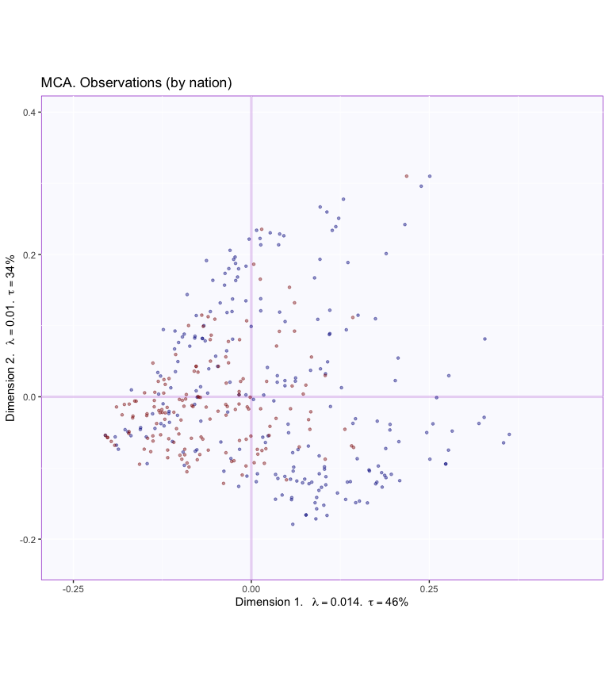

```r
print(d0001.BaseMapNoLabels.Fi)
```

### 6.4.1 Group means, confidence and tolerance intervals

#### 6.4.1.1 Group means

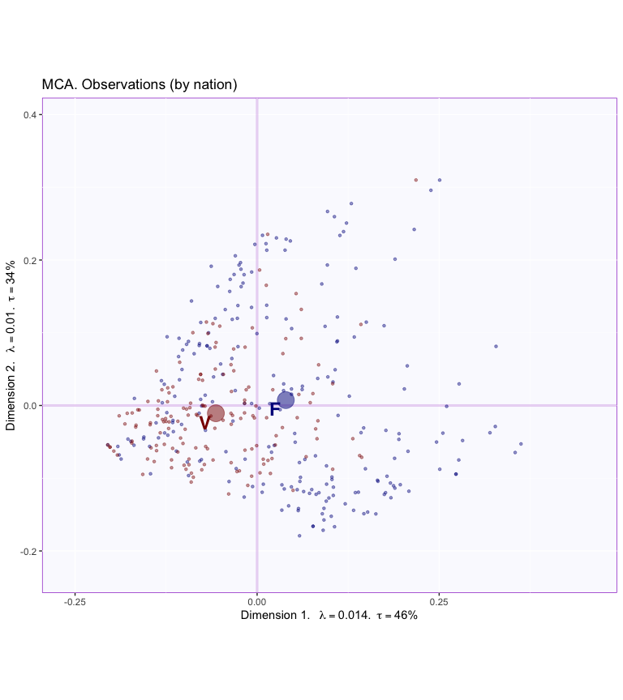

```r
# Bootstrap for CI:
BootCube.Gr <- PTCA4CATA::Boot4Mean(resMCA$ExPosition.Data$fi,
                                 design = cleanData.allVar$nation,
                                 niter = 100,
                                 suppressProgressBar = TRUE)
nationsMeans <- PTCA4CATA::getMeans(resMCA$ExPosition.Data$fi, cleanData.allVar$nation)
# colCity <- c('darkblue', 'red4')
MapGroup <- PTCA4CATA::createFactorMap(nationsMeans,
                            # use the constraint from the main map
                            constraints = BaseMap.Fi$constraints,
                            col.points = colCity,
                            cex = 7,  # size of the dot (bigger)
                            col.labels = colCity,
                            text.cex = 6)
d002.Map.I.withMeans <- d0001.BaseMapNoLabels.Fi  +
                          MapGroup$zeMap_dots + MapGroup$zeMap_text
print(d002.Map.I.withMeans)
```

#### 6.4.1.2 With bootstrapped confidence intervals

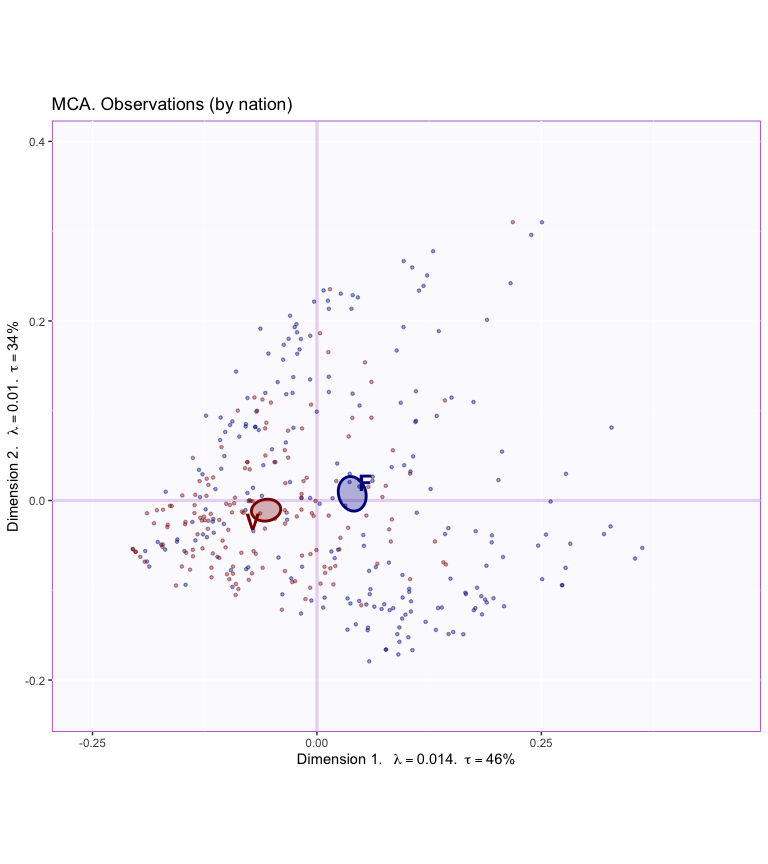

```r
GraphElli <- PTCA4CATA::MakeCIEllipses(BootCube.Gr$BootCube[,1:2,],
                            names.of.factors = c("Dimension 1","Dimension 2"),
                            col = colCity,
                            p.level = .95)
d003.Map.I.withCI <-  d0001.BaseMapNoLabels.Fi +
                          MapGroup$zeMap_text +  GraphElli
print(d003.Map.I.withCI)
```

#### 6.4.1.3 With tolerance convex hulls

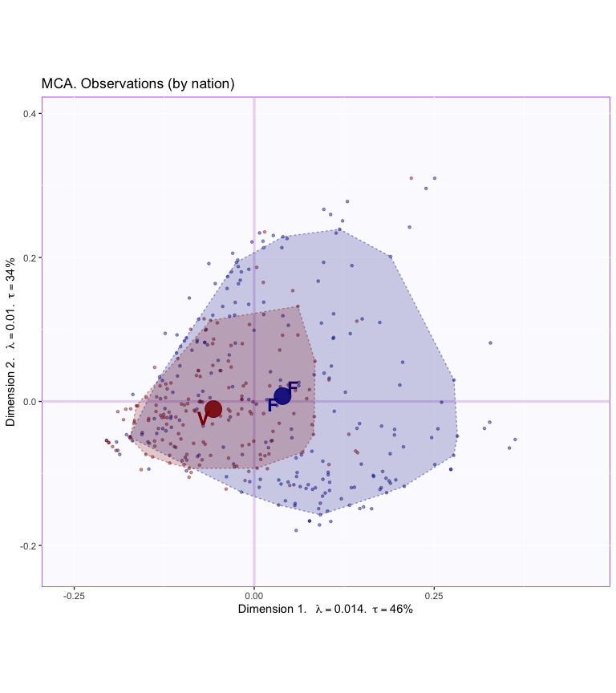

```r
GraphTI.Hull <- PTCA4CATA::MakeToleranceIntervals(resMCA$ExPosition.Data$fi,
                            design = as.factor(cleanData.allVar$nation),
                            # line below is needed
                            names.of.factors =  c("Dim1","Dim2"), # needed
                            col = colCity,
                            line.size = .50,
                            line.type = 3,
                            alpha.ellipse = .2,
                            alpha.line    = .4,
                            p.level       = .75)
#_____________________________________________________________________
# Create the map:
d005.Map.I.withTIHull <- d002.Map.I.withMeans  +
                           GraphTI.Hull + MapGroup$zeMap_dots +
                           MapGroup$zeMap_text + MapGroup$zeMap_dots
#_____________________________________________________________________
# plot it
# dev.new()
print(d005.Map.I.withTIHull)
```

#### 6.4.1.4 Projecting a subsample (of supplementary observations)

```r
Fi.sup  <- resMCA.sup$fii
col     <- 'green'
nI.sup <- nrow(Fi.sup)
col4I.sup <- rep("",nI.sup)
# generate the set of maps
BaseMap.Fi.sup <- createFactorMap(X = Fi.sup , # resMCA$ExPosition.Data$fj,
                              axis1 = axis1, axis2 = axis2,
                              constraints = BaseMap.Fi$constraints,
                              title = '',
                              col.points = 'green',
                              alpha.points = .2, cex = 1.2,
                              col.labels = 'green',
                              text.cex = 2.5,
                              force = 2)
# make the maps
e0001.BaseMapNoLabels.Fi.sup  <- BaseMap.Fi$zeMap_background +
                                   BaseMap.Fi.sup$zeMap_dots +
                                   BaseMap.Fi.sup$zeMap_text +
                                   BaseMap.Fi$zeMap_dots +
  ggplot2::ggtitle('MCA Active and Supplementary Observations') +
                                   labels4MCA
```

```r
 print(e0001.BaseMapNoLabels.Fi.sup)
```

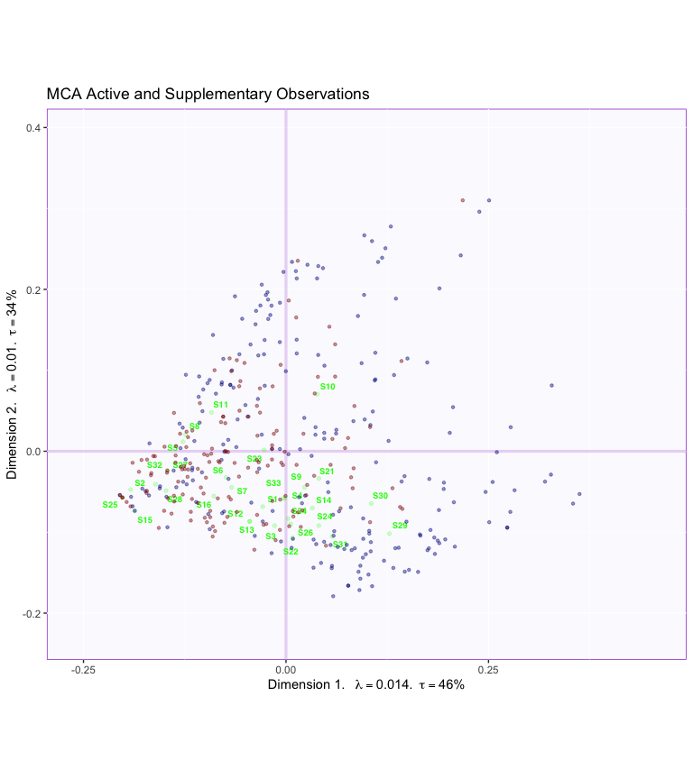

Not surprisingly, the participants of the SPISE2018 meeting are projected closer to the Vietnamese participants than to the French participants.

# 7 Save the graphics as a PowerPoint presentation

The graphics are saved as a PowerPoint presentation called `fermentationFrom2Countries_withJsup.pptx` with the following command

```r
list2Graphs <- PTCA4CATA::saveGraph2pptx(file2Save.pptx = name4Graphs,
                 title = 'Attitudes toward fermented products',
                 addGraphNames = TRUE)
```

Note that we could also have created a power point with `Rmarkdown` by using the following options in the preamble:

```r
output:
      powerpoint_presentation:
           slide_level: 4
```

instead of (for example):

```r
output:
       rmarkdown::html_vignette:
          toc: true
          number_sections: true
```